# Introduction to Data Science - Homework

Mike Powell mpowell3434@floridapoly.edu`

# Problem 1

Load the `tidyverse` package

```r
library(tidyverse)
```

> In this problem you will work with vehicle fuel economy data from the US EPA (Environmental Protection Agency), ranging from 1985-2015.

Read the data using the code below:

```r
vehicles <- read_csv("https://raw.githubusercontent.com/reisanar/datasets/master/vehicles.csv")

vehicles
```

| id | make | model | year | class | trans | drive | cyl | displ | fuel | hwy | cty |
| --- | --- | --- | --- | --- | --- | --- | --- | --- | --- | --- | --- |
| 27550 | AM General | DJ Po Vehicle 2WD | 1984 | Special Purpose Vehicle 2WD | Automatic 3-spd | 2-Wheel Drive | 4 | 2.5 | Regular | 17 | 18 |
| 28426 | AM General | DJ Po Vehicle 2WD | 1984 | Special Purpose Vehicle 2WD | Automatic 3-spd | 2-Wheel Drive | 4 | 2.5 | Regular | 17 | 18 |
| 27549 | AM General | FJ8c Post Office | 1984 | Special Purpose Vehicle 2WD | Automatic 3-spd | 2-Wheel Drive | 6 | 4.2 | Regular | 13 | 13 |
| 28425 | AM General | FJ8c Post Office | 1984 | Special Purpose Vehicle 2WD | Automatic 3-spd | 2-Wheel Drive | 6 | 4.2 | Regular | 13 | 13 |
| 1032 | AM General | Post Office DJ5 2WD | 1985 | Special Purpose Vehicle 2WD | Automatic 3-spd | Rear-Wheel Drive | 4 | 2.5 | Regular | 17 | 16 |
| 1033 | AM General | Post Office DJ8 2WD | 1985 | Special Purpose Vehicle 2WD | Automatic 3-spd | Rear-Wheel Drive | 6 | 4.2 | Regular | 13 | 13 |
| 3347 | ASC Incorporated | GNX | 1987 | Midsize Cars | Automatic 4-spd | Rear-Wheel Drive | 6 | 3.8 | Premium | 21 | 14 |
| 13309 | Acura | 2.2CL/3.0CL | 1997 | Subcompact Cars | Automatic 4-spd | Front-Wheel Drive | 4 | 2.2 | Regular | 26 | 20 |
| 13310 | Acura | 2.2CL/3.0CL | 1997 | Subcompact Cars | Manual 5-spd | Front-Wheel Drive | 4 | 2.2 | Regular | 28 | 22 |
| 13311 | Acura | 2.2CL/3.0CL | 1997 | Subcompact Cars | Automatic 4-spd | Front-Wheel Drive | 6 | 3.0 | Regular | 26 | 18 |

[output cut: 990 more lines]

| Variable | Description |
| --- | --- |
| `id` | Unique EPA identifier |
| `make` | Manufacturer |
| `model` | Model name |
| `year` | Model year |
| `class` | EPA vehicle size class |
| `trans` | Transmission |
| `drive` | Drive train |
| `cyl` | Number of cylinders |
| `displ` | Engine displacement, in litres |
| `fuel` | Fuel type |
| `hwy` | Highway fuel economy, in mpg |
| `cty` | City fuel economy, in mpg |

1. (6 points) **Select** the different manufacturers (makes) of the cars in this data set. Save this vector in a variable called `makes`

```r
# Solution for 1A:

makes <- select(vehicles, make)
```

2. (6 points) Can you determine **how many different car manufacturers** are represented by the data set?

```r
# Solution for 1B:

#distinct()  works as well

makes %>%
  group_by(make) %>%
  summarise(count = n()) %>%
  nrow()
```

```
[1] 128
```

3. (6 points) **Filter** the data set for vehicles manufactured in 1998.

```r
# Solution for 1C:

filter(vehicles, year == 1998)
```

| id | make | model | year | class | trans | drive | cyl | displ | fuel | hwy | cty |
| --- | --- | --- | --- | --- | --- | --- | --- | --- | --- | --- | --- |
| 14038 | Acura | 2.3CL/3.0CL | 1998 | Subcompact Cars | Automatic 4-spd | Front-Wheel Drive | 4 | 2.3 | Regular | 27 | 19 |
| 14039 | Acura | 2.3CL/3.0CL | 1998 | Subcompact Cars | Manual 5-spd | Front-Wheel Drive | 4 | 2.3 | Regular | 29 | 21 |
| 14040 | Acura | 2.3CL/3.0CL | 1998 | Subcompact Cars | Automatic 4-spd | Front-Wheel Drive | 6 | 3.0 | Regular | 26 | 17 |
| 14163 | Acura | 2.5TL/3.2TL | 1998 | Compact Cars | Automatic 4-spd | Front-Wheel Drive | 5 | 2.5 | Premium | 23 | 17 |
| 14164 | Acura | 2.5TL/3.2TL | 1998 | Compact Cars | Automatic 4-spd | Front-Wheel Drive | 6 | 3.2 | Premium | 22 | 17 |
| 14278 | Acura | 3.5RL | 1998 | Midsize Cars | Automatic 4-spd | Front-Wheel Drive | 6 | 3.5 | Premium | 23 | 17 |
| 14041 | Acura | Integra | 1998 | Subcompact Cars | Automatic 4-spd | Front-Wheel Drive | 4 | 1.8 | Regular | 29 | 21 |
| 14042 | Acura | Integra | 1998 | Subcompact Cars | Manual 5-spd | Front-Wheel Drive | 4 | 1.8 | Regular | 29 | 22 |
| 14043 | Acura | Integra | 1998 | Subcompact Cars | Manual 5-spd | Front-Wheel Drive | 4 | 1.8 | Premium | 28 | 22 |
| 13984 | Acura | NSX | 1998 | Two Seaters | Automatic 4-spd | Rear-Wheel Drive | 6 | 3.0 | Premium | 22 | 16 |

[output cut: 801 more lines]

```r
NA
```

4. (6 points) **Mutate** the 1998 cars data frame to add a column `average` that has the average gas mileage (between city and highway MPG) for each car

```r
# Solution for 1D:

avg <- filter(vehicles, year == 1998) %>%
  mutate(
       avg = (cty + hwy)/2)

avg
```

| id | make | model | year | class | trans | drive | cyl | displ | fuel | hwy | cty | avg |
| --- | --- | --- | --- | --- | --- | --- | --- | --- | --- | --- | --- | --- |
| 14038 | Acura | 2.3CL/3.0CL | 1998 | Subcompact Cars | Automatic 4-spd | Front-Wheel Drive | 4 | 2.3 | Regular | 27 | 19 | 23.0 |
| 14039 | Acura | 2.3CL/3.0CL | 1998 | Subcompact Cars | Manual 5-spd | Front-Wheel Drive | 4 | 2.3 | Regular | 29 | 21 | 25.0 |
| 14040 | Acura | 2.3CL/3.0CL | 1998 | Subcompact Cars | Automatic 4-spd | Front-Wheel Drive | 6 | 3.0 | Regular | 26 | 17 | 21.5 |
| 14163 | Acura | 2.5TL/3.2TL | 1998 | Compact Cars | Automatic 4-spd | Front-Wheel Drive | 5 | 2.5 | Premium | 23 | 17 | 20.0 |
| 14164 | Acura | 2.5TL/3.2TL | 1998 | Compact Cars | Automatic 4-spd | Front-Wheel Drive | 6 | 3.2 | Premium | 22 | 17 | 19.5 |
| 14278 | Acura | 3.5RL | 1998 | Midsize Cars | Automatic 4-spd | Front-Wheel Drive | 6 | 3.5 | Premium | 23 | 17 | 20.0 |
| 14041 | Acura | Integra | 1998 | Subcompact Cars | Automatic 4-spd | Front-Wheel Drive | 4 | 1.8 | Regular | 29 | 21 | 25.0 |
| 14042 | Acura | Integra | 1998 | Subcompact Cars | Manual 5-spd | Front-Wheel Drive | 4 | 1.8 | Regular | 29 | 22 | 25.5 |
| 14043 | Acura | Integra | 1998 | Subcompact Cars | Manual 5-spd | Front-Wheel Drive | 4 | 1.8 | Premium | 28 | 22 | 25.0 |
| 13984 | Acura | NSX | 1998 | Two Seaters | Automatic 4-spd | Rear-Wheel Drive | 6 | 3.0 | Premium | 22 | 16 | 19.0 |

[output cut: 801 more lines]

```r
NA
```

5. (6 points) Of all vehicles, what is the vehicle ID of the vehicle with the worst highway MPG?

# worst milage look at e and f filter and select

```r
# Solution for 1E:

filter(vehicles,
         hwy <= min(hwy)) %>%
select(id, make)
```

| id | make |
| --- | --- |
| 1178 | Aston Martin |
| 47 | Aston Martin |
| 1179 | Aston Martin |
| 48 | Aston Martin |
| 3308 | Rolls-Royce |
| 3110 | Rolls-Royce |
| 3113 | Rolls-Royce |
| 3115 | Rolls-Royce |
| 3444 | Rolls-Royce |
| 3447 | Rolls-Royce |

[output cut: 3 more lines]

```r
NA
```

6. (6 points) Which 2013 Acura model has the best highway MPG? Which 2015 Honda model has the best highway MPG?

```r
# Solution for 1F:

filter(vehicles, year == 2013, make == "Acura" ) %>%
filter(hwy >= max(hwy)) %>%
select(id, make)
```

| id | make |
| --- | --- |
| 33148 | Acura |

```r
filter(vehicles, year == 2015, make == "Honda" ) %>%
filter(hwy >= max(hwy)) %>%
select(id, make)
```

| id | make |
| --- | --- |
| 34855 | Honda |

7. (6 points) Create a **data visualization** of your choice using this dataset. Comment on the results.

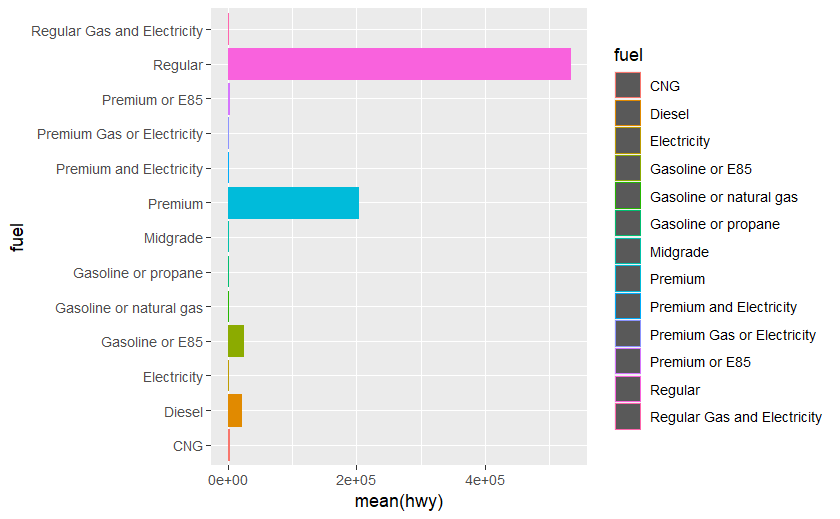

```r
# Solution for 1G:

ggplot(vehicles, mapping = aes(x = fuel, y = mean(hwy), color = fuel)) +
  geom_bar(stat="identity") +
  coord_flip()
```

# Problem 2

Load the `nycflights13` package.

```r
library(nycflights13)

flights
```

| year | month | day | dep_time | sched_dep_time | dep_delay | arr_time | sched_arr_time | arr_delay | carrier | flight | tailnum | origin | dest | air_time | distance | hour | minute | time_hour |
| --- | --- | --- | --- | --- | --- | --- | --- | --- | --- | --- | --- | --- | --- | --- | --- | --- | --- | --- |
| 2013 | 1 | 1 | 517 | 515 | 2 | 830 | 819 | 11 | UA | 1545 | N14228 | EWR | IAH | 227 | 1400 | 5 | 15 | 2013-01-01 05:00:00 |
| 2013 | 1 | 1 | 533 | 529 | 4 | 850 | 830 | 20 | UA | 1714 | N24211 | LGA | IAH | 227 | 1416 | 5 | 29 | 2013-01-01 05:00:00 |
| 2013 | 1 | 1 | 542 | 540 | 2 | 923 | 850 | 33 | AA | 1141 | N619AA | JFK | MIA | 160 | 1089 | 5 | 40 | 2013-01-01 05:00:00 |
| 2013 | 1 | 1 | 544 | 545 | -1 | 1004 | 1022 | -18 | B6 | 725 | N804JB | JFK | BQN | 183 | 1576 | 5 | 45 | 2013-01-01 05:00:00 |
| 2013 | 1 | 1 | 554 | 600 | -6 | 812 | 837 | -25 | DL | 461 | N668DN | LGA | ATL | 116 | 762 | 6 | 0 | 2013-01-01 06:00:00 |
| 2013 | 1 | 1 | 554 | 558 | -4 | 740 | 728 | 12 | UA | 1696 | N39463 | EWR | ORD | 150 | 719 | 5 | 58 | 2013-01-01 05:00:00 |
| 2013 | 1 | 1 | 555 | 600 | -5 | 913 | 854 | 19 | B6 | 507 | N516JB | EWR | FLL | 158 | 1065 | 6 | 0 | 2013-01-01 06:00:00 |
| 2013 | 1 | 1 | 557 | 600 | -3 | 709 | 723 | -14 | EV | 5708 | N829AS | LGA | IAD | 53 | 229 | 6 | 0 | 2013-01-01 06:00:00 |
| 2013 | 1 | 1 | 557 | 600 | -3 | 838 | 846 | -8 | B6 | 79 | N593JB | JFK | MCO | 140 | 944 | 6 | 0 | 2013-01-01 06:00:00 |
| 2013 | 1 | 1 | 558 | 600 | -2 | 753 | 745 | 8 | AA | 301 | N3ALAA | LGA | ORD | 138 | 733 | 6 | 0 | 2013-01-01 06:00:00 |

[output cut: 990 more lines]

> Use the `flights` dataframe to answer the following questions.
1. (6 points) Find all flights headed to MCO, and **select** only the origin, destination, and the departure time.

```r
# Solution for 2A:

flights %>%
  filter(dest == "MCO") %>%
  select(origin, dest,  dep_time)
```

| origin | dest | dep_time |
| --- | --- | --- |
| JFK | MCO | 557 |
| LGA | MCO | 637 |
| JFK | MCO | 656 |
| JFK | MCO | 719 |
| EWR | MCO | 732 |
| LGA | MCO | 752 |
| EWR | MCO | 758 |
| JFK | MCO | 804 |
| EWR | MCO | 829 |
| LGA | MCO | 859 |

[output cut: 990 more lines]

```r
NA
NA
```

2. (6 points) Consider flights from JFK to TPA. What was the **average, minimum, and maximum** *air time* of those flights?

```r
# Solution for 2B:

flights %>%
  filter(origin == "JFK", dest == "TPA") %>%

summarise(avg_air_time = mean(air_time, na.rm = T),
          min_air_time = min(air_time, na.rm = T),
          max_air_time = max(air_time, na.rm = T))
```

| avg_air_time | min_air_time | max_air_time |
| --- | --- | --- |
| 144.2784 | 118 | 200 |

3. (6 points) What was the **average departure delay** in each month? Save this as a data frame `dep_delay_by_month`. (Hint: you may have to perform a grouping operation then summarizing your data).

```r
# Solution for 2C:

dep_delay_by_month <- flights %>%
  group_by(month) %>%
  summarise(avg_dep_delay = mean(dep_delay, na.rm = T))
dep_delay_by_month
```

| month | avg_dep_delay |
| --- | --- |
| 1 | 10.036665 |
| 2 | 10.816843 |
| 3 | 13.227076 |
| 4 | 13.938038 |
| 5 | 12.986859 |
| 6 | 20.846332 |
| 7 | 21.727787 |
| 8 | 12.611040 |
| 9 | 6.722476 |
| 10 | 6.243988 |

[output cut: 2 more lines]

```r
NA
```

4. (8 points) Which month had the **largest average departure delay**?

```r
# Solution for 2D:

dep_delay_by_month %>%
  arrange(-avg_dep_delay)
```

| month | avg_dep_delay |
| --- | --- |
| 7 | 21.727787 |
| 6 | 20.846332 |
| 12 | 16.576688 |
| 4 | 13.938038 |
| 3 | 13.227076 |
| 5 | 12.986859 |
| 8 | 12.611040 |
| 2 | 10.816843 |
| 1 | 10.036665 |
| 9 | 6.722476 |

[output cut: 2 more lines]

```r
NA
```

5. (8 points) To which destinations were the **average arrival delays the highest**?

```r
# Solution for 2E:

highest_avg_arr_delay <- flights %>%
  group_by(dest) %>%
  summarise(
    avg_arr_delays = mean(arr_delay, na.rm = T)) %>%
      arrange(-avg_arr_delays)

highest_avg_arr_delay
```

| dest | avg_arr_delays |
| --- | --- |
| CAE | 41.76415094 |
| TUL | 33.65986395 |
| OKC | 30.61904762 |
| JAC | 28.09523810 |
| TYS | 24.06920415 |
| MSN | 20.19604317 |
| RIC | 20.11125320 |
| CAK | 19.69833729 |
| DSM | 19.00573614 |
| GRR | 18.18956044 |

[output cut: 95 more lines]

```r
NA
NA
```

6. (6 points) Which airline had the **smallest average arrival delay**?

```r
# Solution for 2F:

smallest_avg_arr_delay <- flights %>%
  group_by(dest) %>%
  summarise(
    avg_arr_delays = mean(arr_delay, na.rm = T)) %>%
      arrange(avg_arr_delays)

smallest_avg_arr_delay
```

| dest | avg_arr_delays |
| --- | --- |
| LEX | -22.00000000 |
| PSP | -12.72222222 |
| SNA | -7.86822660 |
| STT | -3.83590734 |
| ANC | -2.50000000 |
| HNL | -1.36519258 |
| SEA | -1.09909910 |
| MVY | -0.28571429 |
| LGB | -0.06202723 |
| SLC | 0.17625459 |

[output cut: 95 more lines]

```r
NA
```

7. (6 points) Find all flights that were operated by United, American, or Delta.

```r
# Solution for 2G:
condensed_flights <- flights %>%
  filter(carrier == c("UA", "AA", "DL", na.rm = T))

condensed_flights
```

| year | month | day | dep_time | sched_dep_time | dep_delay | arr_time | sched_arr_time | arr_delay | carrier | flight | tailnum | origin | dest | air_time | distance | hour | minute | time_hour |
| --- | --- | --- | --- | --- | --- | --- | --- | --- | --- | --- | --- | --- | --- | --- | --- | --- | --- | --- |
| 2013 | 1 | 1 | 517 | 515 | 2 | 830 | 819 | 11 | UA | 1545 | N14228 | EWR | IAH | 227 | 1400 | 5 | 15 | 2013-01-01 05:00:00 |
| 2013 | 1 | 1 | 558 | 600 | -2 | 753 | 745 | 8 | AA | 301 | N3ALAA | LGA | ORD | 138 | 733 | 6 | 0 | 2013-01-01 06:00:00 |
| 2013 | 1 | 1 | 558 | 600 | -2 | 924 | 917 | 7 | UA | 194 | N29129 | JFK | LAX | 345 | 2475 | 6 | 0 | 2013-01-01 06:00:00 |
| 2013 | 1 | 1 | 559 | 600 | -1 | 854 | 902 | -8 | UA | 1187 | N76515 | EWR | LAS | 337 | 2227 | 6 | 0 | 2013-01-01 06:00:00 |
| 2013 | 1 | 1 | 607 | 607 | 0 | 858 | 915 | -17 | UA | 1077 | N53442 | EWR | MIA | 157 | 1085 | 6 | 7 | 2013-01-01 06:00:00 |
| 2013 | 1 | 1 | 623 | 627 | -4 | 933 | 932 | 1 | UA | 496 | N459UA | LGA | IAH | 229 | 1416 | 6 | 27 | 2013-01-01 06:00:00 |
| 2013 | 1 | 1 | 655 | 655 | 0 | 1021 | 1030 | -9 | DL | 1415 | N3763D | JFK | SLC | 294 | 1990 | 6 | 55 | 2013-01-01 06:00:00 |
| 2013 | 1 | 1 | 656 | 700 | -4 | 854 | 850 | 4 | AA | 305 | N4WNAA | LGA | ORD | 143 | 733 | 7 | 0 | 2013-01-01 07:00:00 |
| 2013 | 1 | 1 | 656 | 700 | -4 | 948 | 1011 | -23 | UA | 1115 | N24212 | EWR | TPA | 156 | 997 | 7 | 0 | 2013-01-01 07:00:00 |
| 2013 | 1 | 1 | 658 | 700 | -2 | 944 | 939 | 5 | DL | 1547 | N6703D | LGA | ATL | 126 | 762 | 7 | 0 | 2013-01-01 07:00:00 |

[output cut: 990 more lines]

```r
NA
NA
```

8. (6 points) Find all the flights (if any) headed to Orlando, Tampa, or Miami with a scheduled departure time later than 8:00 PM.

```r
# Solution for 2H:

flights %>%
  filter(dest == c("MCO", "TPA", "MIA", na.rm = T)) %>%
           filter(dep_time >= 800)
```

| year | month | day | dep_time | sched_dep_time | dep_delay | arr_time | sched_arr_time | arr_delay | carrier | flight | tailnum | origin | dest | air_time | distance | hour | minute | time_hour |
| --- | --- | --- | --- | --- | --- | --- | --- | --- | --- | --- | --- | --- | --- | --- | --- | --- | --- | --- |
| 2013 | 1 | 1 | 829 | 830 | -1 | 1117 | 1140 | -23 | UA | 1592 | N75425 | EWR | MCO | 145 | 937 | 8 | 30 | 2013-01-01 08:00:00 |
| 2013 | 1 | 1 | 853 | 845 | 8 | 1147 | 1145 | 2 | B6 | 59 | N184JB | JFK | TPA | 159 | 1005 | 8 | 45 | 2013-01-01 08:00:00 |
| 2013 | 1 | 1 | 930 | 905 | 25 | 1218 | 1209 | 9 | UA | 1148 | N57439 | EWR | TPA | 149 | 997 | 9 | 5 | 2013-01-01 09:00:00 |
| 2013 | 1 | 1 | 1222 | 1229 | -7 | 1520 | 1526 | -6 | B6 | 27 | N192JB | JFK | TPA | 160 | 1005 | 12 | 29 | 2013-01-01 12:00:00 |
| 2013 | 1 | 1 | 1320 | 1315 | 5 | 1602 | 1605 | -3 | B6 | 393 | N537JB | LGA | MCO | 140 | 950 | 13 | 15 | 2013-01-01 13:00:00 |
| 2013 | 1 | 1 | 1339 | 1345 | -6 | 1642 | 1705 | -23 | AA | 1073 | N3EMAA | LGA | MIA | 161 | 1096 | 13 | 45 | 2013-01-01 13:00:00 |
| 2013 | 1 | 1 | 1355 | 1356 | -1 | 1646 | 1650 | -4 | B6 | 1783 | N709JB | JFK | MCO | 144 | 944 | 13 | 56 | 2013-01-01 13:00:00 |
| 2013 | 1 | 1 | 1442 | 1450 | -8 | 1728 | 1755 | -27 | AA | 1813 | N5FMAA | JFK | MCO | 141 | 944 | 14 | 50 | 2013-01-01 14:00:00 |
| 2013 | 1 | 1 | 1520 | 1520 | 0 | 1817 | 1816 | 1 | UA | 1593 | N13750 | EWR | MCO | 152 | 937 | 15 | 20 | 2013-01-01 15:00:00 |
| 2013 | 1 | 1 | 1740 | 1630 | 70 | 2102 | 1954 | 68 | DL | 2139 | N369NW | LGA | MIA | 167 | 1096 | 16 | 30 | 2013-01-01 16:00:00 |

[output cut: 990 more lines]

```r
NA
```

1. (6 points) Create a **data visualization** of your choice using this dataset. Comment on the results.

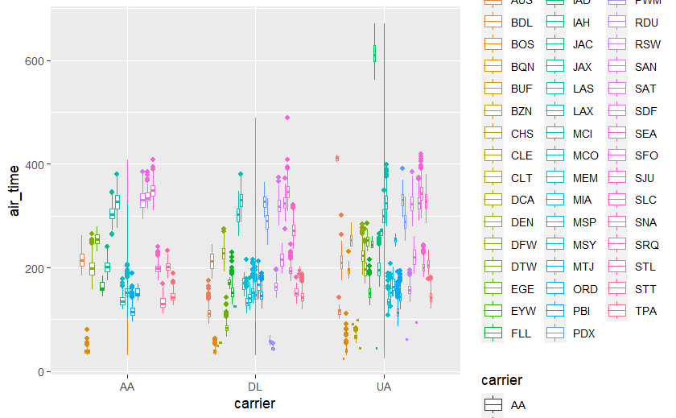

```r
# Solution for 2I:

condensed_flights %>%
  ggplot(mapping = aes(x = carrier, y = air_time, color = dest, shape = carrier, na.rm = T)) +
geom_boxplot() +
  geom_line(aes(group = carrier))
```